# **Problem Statement**

## **Business Context**

Workplace safety in hazardous environments like construction sites and industrial plants is crucial to prevent accidents and injuries. One of the most important safety measures is ensuring workers wear safety helmets, which protect against head injuries from falling objects and machinery. Non-compliance with helmet regulations increases the risk of serious injuries or fatalities, making effective monitoring essential, especially in large-scale operations where manual oversight is prone to errors and inefficiency.

To overcome these challenges, SafeGuard Corp plans to develop an automated image analysis system capable of detecting whether workers are wearing safety helmets. This system will improve safety enforcement, ensuring compliance and reducing the risk of head injuries. By automating helmet monitoring, SafeGuard aims to enhance efficiency, scalability, and accuracy, ultimately fostering a safer work environment while minimizing human error in safety oversight.

## **Objective**

As a data scientist at SafeGuard Corp, you are tasked with developing an image classification model that classifies images into one of two categories:

- **With Helmet:** Workers wearing safety helmets.
- **Without Helmet:** Workers not wearing safety helmets.

## **Data Description**

The dataset consists of **631 images**, equally divided into two categories:

- **With Helmet:** 311 images showing workers wearing helmets.
- **Without Helmet:** 320 images showing workers not wearing helmets.

**Dataset Characteristics:**

- **Variations in Conditions:** Images include diverse environments such as construction sites, factories, and industrial settings, with variations in lighting, angles, and worker postures to simulate real-world conditions.
- **Worker Activities:** Workers are depicted in different actions such as standing, using tools, or moving, ensuring robust model learning for various scenarios.

# **Installing and Importing the Necessary Libraries**

```python
# !pip install tensorflow[and-cuda] numpy==1.25.2 -q

!pip install -U pip setuptools wheel

# install TF + CUDA-enabled wheels with a compatible NumPy
!pip install -U "tensorflow[and-cuda]==2.17.*" "numpy>=1.26.4,<2.1"
```

```python
# Import TensorFlow
import tensorflow as tf

# Print the installed TensorFlow version
print("TF:", tf.__version__)

# Count how many GPUs are available to TensorFlow
print("Num GPUs Available:", len(tf.config.list_physical_devices('GPU')))

# List GPU devices recognized by TensorFlow
print("GPU:", tf.config.list_physical_devices('GPU'))
```

```
TF: 2.17.1
Num GPUs Available: 1
GPU: [PhysicalDevice(name='/physical_device:GPU:0', device_type='GPU')]
```

**Note:**

- After running the above cell, kindly restart the notebook kernel (for Jupyter Notebook) or runtime (for Google Colab) and run all cells sequentially from the next cell.
- On executing the above line of code, you might see a warning regarding package dependencies. This error message can be ignored as the above code ensures that all necessary libraries and their dependencies are maintained to successfully execute the code in this notebook.

```python
import os
import random
import numpy as np                                                                               # Importing numpy for Matrix Operations
import pandas as pd
import seaborn as sns
import matplotlib.image as mpimg                                                                 # Importing pandas to read CSV files
import matplotlib.pyplot as plt                                                                  # Importting matplotlib for Plotting and visualizing images
import math                                                                                      # Importing math module to perform mathematical operations
import cv2


# Tensorflow modules
import keras
import tensorflow as tf
from tensorflow.keras.preprocessing.image import ImageDataGenerator                              # Importing the ImageDataGenerator for data augmentation
from tensorflow.keras.models import Sequential                                                   # Importing the sequential module to define a sequential model
from tensorflow.keras.layers import Dense,Dropout,Flatten,Conv2D,MaxPooling2D,BatchNormalization # Defining all the layers to build our CNN Model
from tensorflow.keras.optimizers import Adam,SGD                                                 # Importing the optimizers which can be used in our model
from sklearn import preprocessing                                                                # Importing the preprocessing module to preprocess the data
from sklearn.model_selection import train_test_split                                             # Importing train_test_split function to split the data into train and test
from sklearn.metrics import confusion_matrix
from tensorflow.keras.models import Model
from keras.applications.vgg16 import VGG16                                                       # Importing confusion_matrix to plot the confusion matrix

# Display images using OpenCV
from google.colab.patches import cv2_imshow

#Imports functions for evaluating the performance of machine learning models
from sklearn.metrics import confusion_matrix, f1_score,accuracy_score, recall_score, precision_score, classification_report
from sklearn.metrics import mean_squared_error as mse                                                 # Importing cv2_imshow from google.patches to display images

# Ignore warnings
import warnings
warnings.filterwarnings('ignore')
```

```python
# Set the seed using keras.utils.set_random_seed. This will set:
# 1) `numpy` seed
# 2) backend random seed
# 3) `python` random seed
tf.keras.utils.set_random_seed(812)
```

# **Data Overview**

## Loading the data

```python
from google.colab import drive
drive.mount('/content/drive')
```

```python
images = np.load('/content/drive/MyDrive/Data_Science/PGP-AIML/Projects/Project6- HelmNet/images_proj.npy')

labels = pd.read_csv('/content/drive/MyDrive/Data_Science/PGP-AIML/Projects/Project6- HelmNet/Labels_proj.csv')
```

```python
print("Images file shape:", images.shape)
print("Labels file shape:", labels.shape)
# print(f"Images shape: {images.shape}, Labels shape: {labels.shape}")
```

```
Images file shape: (631, 200, 200, 3)
Labels file shape: (631, 1)
```

# **Exploratory Data Analysis**

### Plot random images from each of the classes and print their corresponding labels.

[figure not shown]

```python
# Get the indices of images belonging to each class# Get the indices of images belonging to each class
# Indices of all samples where label == 1  → "Helmet" class
helmet_indices = np.where(labels == 1)[0]
# Indices of all samples where label == 0  → "No Helmet" class
no_helmet_indices = np.where(labels == 0)[0]

# Select one image from each class
helmet_img = images[np.random.choice(helmet_indices)]
no_helmet_img = images[np.random.choice(no_helmet_indices)]

# Plot the images
fig, axes = plt.subplots(1, 2, figsize=(8, 4))

# Display "With Helmet" image
axes[0].imshow(helmet_img)
axes[0].set_title("Worker WITH Helmet")
axes[0].axis('off')

# Display "Without Helmet" image
axes[1].imshow(no_helmet_img)
axes[1].set_title("Worker WITHOUT Helmet")
axes[1].axis('off')

# Show the plots
plt.tight_layout()
plt.show()
```

## Checking for class imbalance

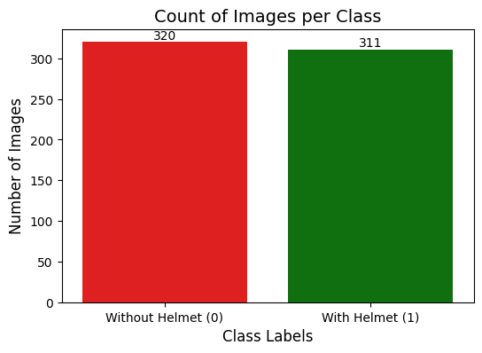

```python
# Create a count plot
plt.figure(figsize=(6, 4))
ax = sns.countplot(x=labels.iloc[:, 0], palette=['red', 'green'])

# Add exact counts on top of bars
for p in ax.patches:
    ax.annotate(f'{int(p.get_height())}', (p.get_x() + p.get_width() / 2, p.get_height()),
                ha='center', va='bottom', fontsize=10, )

# Add labels
plt.xlabel("Class Labels", fontsize=12)
plt.ylabel("Number of Images", fontsize=12)
plt.title("Count of Images per Class", fontsize=14)
plt.xticks(ticks=[0, 1], labels=["Without Helmet (0)", "With Helmet (1)"])  # Rename x-axis labels

# Show plot
plt.show()
```

Observations from EPA:

1. Dataset makeup
   - Total images: 631
   - Class balance: With Helmet = 311, Without Helmet = 320 → effectively balanced (~49%/51%), so no strong class-imbalance concerns.
2. Image properties & preprocessing
   - Images are treated as RGB and resized to 200×200×3 for modeling.
   - Pixel range: raw images are in 0–255; I normalize to 0–1 by dividing by 255, which preserves visual appearance but stabilizes training.
   - No missing labels detected; labels are binary {0,1}.
3. Variability in data (useful for generalization)
   - Images cover diverse environments, viewing angles, lighting conditions, and worker postures/activities, which is beneficial for training models that generalize to realistic scenes.
4. Sample inspections
   - Visual checks of random samples (from both classes) show clear visual cues for helmet presence (shape/color/position on the head), supporting learnability.
5. Practical implications
   - Since classes are balanced and features are visually distinctive, accuracy is meaningful, but for safety use-cases I am prioritizing Recall for the “No Helmet” class.
   - The diversity in background/lighting/pose suggests data augmentation (small rotations/shifts/zoom/brightness jitter) is appropriate to further improve robustness without creating label noise.

# **Data Preprocessing**

## Converting images to grayscale

As grayscale simplifies the data while retaining essential structural features, we can convert the images to grayscale

[figure not shown]

```python
import random

# Convert all images in the dataset to grayscale
images_gray = []
for i in range(len(images)):
    img_gray = cv2.cvtColor(images[i], cv2.COLOR_BGR2GRAY)  # Convert RGB image to grayscale (1 channel)
    images_gray.append(img_gray)

# Pick a random index from the grayscale image list
n = random.randint(0, len(images_gray) - 1)

# Display the randomly chosen grayscale image
cv2_imshow(images_gray[n])
```

### Splitting the dataset

```python
from sklearn.model_selection import train_test_split

# 70% train, 15% validation, 15% test split
X_train, X_temp, y_train, y_temp = train_test_split(
    np.array(images), labels,
    test_size=0.3,   # 30% goes to temp (val + test)
    random_state=42,
    stratify=labels
)

X_val, X_test, y_val, y_test = train_test_split(
    X_temp, y_temp,
    test_size=0.5,   # split temp evenly: 15% val, 15% test
    random_state=42,
    stratify=y_temp
)
```

Here, I used stratified splits to maintain the class ratio across train/val/test, preventing distribution drift between splits.

```python
print("Shape of training data: ", X_train.shape, y_train.shape)   # shape of training data
print("Shape of validation data: ", X_val.shape, y_val.shape)     # shape of validation data
print("Shape of test data: ", X_test.shape, y_test.shape)         # shape of test data
```

```
Shape of training data:  (441, 200, 200, 3) (441, 1)
Shape of validation data:  (95, 200, 200, 3) (95, 1)
Shape of test data:  (95, 200, 200, 3) (95, 1)
```

### Data Normalization

Since the image pixel values range from 0-255, our method of normalization here will be scaling - we shall divide all the pixel values by 255 to standardize the images to have values between 0-1.

```python
X_train_normalized = X_train.astype('float32') / 255.0
X_val_normalized = X_val.astype('float32') / 255.0
X_test_normalized = X_test.astype('float32') / 255.0

# This converts all pixel values from the range 0–255 to 0–1, which generally helps neural networks train faster and more stably.
```

```python
# Verify normalization
# Min should be 0.0
# Max should be 1.0

print("Training set range:", X_train_normalized.min(), "to", X_train_normalized.max())
print("Validation set range:", X_val_normalized.min(), "to", X_val_normalized.max())
print("Test set range:", X_test_normalized.min(), "to", X_test_normalized.max())
```

```
Training set range: 0.0 to 1.0
Validation set range: 0.0 to 1.0
Test set range: 0.0 to 1.0
```

A quick visualization comparing a sample image before and after normalization to confirm it visually

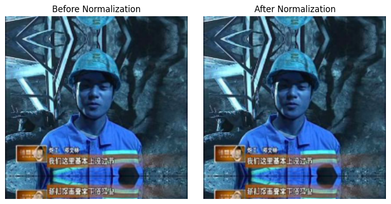

```
Before normalization: 0 to 255
After normalization: 0.0 to 1.0
```

```python
import matplotlib.pyplot as plt

# Pick a sample index
n = random.randint(0, len(X_train) - 1)

# Plot before and after normalization
fig, axes = plt.subplots(1, 2, figsize=(8, 4))

axes[0].imshow(X_train[n].astype('uint8'))  # original image
axes[0].set_title("Before Normalization")
axes[0].axis('off')

axes[1].imshow(X_train_normalized[n])       # normalized image
axes[1].set_title("After Normalization")
axes[1].axis('off')

plt.tight_layout()
plt.show()

# Print pixel value ranges
print("Before normalization:", X_train[n].min(), "to", X_train[n].max())
print("After normalization:", X_train_normalized[n].min(), "to", X_train_normalized[n].max())
```

# **Model Building**

## Utility Functions

```python
# defining a function to compute different metrics to check performance of a classification model built using statsmodels
def model_performance_classification(model, predictors, target):
    """
    Function to compute different metrics to check classification model performance

    model: classifier
    predictors: independent variables
    target: dependent variable
    """

    # checking which probabilities are greater than threshold
    pred = model.predict(predictors).reshape(-1)>0.5

    target = target.to_numpy().reshape(-1)


    acc = accuracy_score(target, pred)  # to compute Accuracy
    recall = recall_score(target, pred, average='weighted')  # to compute Recall
    precision = precision_score(target, pred, average='weighted')  # to compute Precision
    f1 = f1_score(target, pred, average='weighted')  # to compute F1-score

    # creating a dataframe of metrics
    df_perf = pd.DataFrame({"Accuracy": acc, "Recall": recall, "Precision": precision, "F1 Score": f1,},index=[0],)

    return df_perf
```

```python
def plot_confusion_matrix(model,predictors,target,ml=False):
    """
    Function to plot the confusion matrix

    model: classifier
    predictors: independent variables
    target: dependent variable
    ml: To specify if the model used is an sklearn ML model or not (True means ML model)
    """

    # checking which probabilities are greater than threshold
    pred = model.predict(predictors).reshape(-1)>0.5

    target = target.to_numpy().reshape(-1)

    # Plotting the Confusion Matrix using confusion matrix() function which is also predefined tensorflow module
    confusion_matrix = tf.math.confusion_matrix(target,pred)
    f, ax = plt.subplots(figsize=(10, 8))
    sns.heatmap(
        confusion_matrix,
        annot=True,
        linewidths=.4,
        fmt="d",
        square=True,
        ax=ax
    )
    plt.show()
```

## Model 1: Simple Convolutional Neural Network (CNN)

```python
# Initializing Model
model_1 = Sequential()

# Convolutional layers
model_1.add(Conv2D(32, (3, 3), activation='relu', padding="same", input_shape=(200, 200, 3)))  # input image shape
model_1.add(MaxPooling2D((4, 4), padding='same'))
model_1.add(Conv2D(64, (3, 3), activation='relu', padding="same"))  # 64 filters, 3x3, relu
model_1.add(MaxPooling2D((2, 2), padding='same'))                   # 2x2 pooling
model_1.add(Conv2D(128, (3, 3), activation='relu', padding="same")) # 128 filters, 3x3, relu

# Flatten and Dense layers
model_1.add(Flatten())
model_1.add(Dense(4, activation='relu'))
model_1.add(Dense(1, activation='sigmoid'))  # binary output

# Compile with Adam Optimizer
opt = Adam(learning_rate=1e-3)
model_1.compile(optimizer=opt, loss='binary_crossentropy', metrics=["accuracy", "Recall"])

# Summary
model_1.summary()
```

```
Model: "sequential"
```

```
┏━━━━━━━━━━━━━━━━━━━━━━━━━━━━━━━━━┳━━━━━━━━━━━━━━━━━━━━━━━━┳━━━━━━━━━━━━━━━┓
┃ Layer (type)                    ┃ Output Shape           ┃       Param # ┃
┡━━━━━━━━━━━━━━━━━━━━━━━━━━━━━━━━━╇━━━━━━━━━━━━━━━━━━━━━━━━╇━━━━━━━━━━━━━━━┩
│ conv2d (Conv2D)                 │ (None, 200, 200, 32)   │           896 │
├─────────────────────────────────┼────────────────────────┼───────────────┤
│ max_pooling2d (MaxPooling2D)    │ (None, 50, 50, 32)     │             0 │
├─────────────────────────────────┼────────────────────────┼───────────────┤
│ conv2d_1 (Conv2D)               │ (None, 50, 50, 64)     │        18,496 │
├─────────────────────────────────┼────────────────────────┼───────────────┤
│ max_pooling2d_1 (MaxPooling2D)  │ (None, 25, 25, 64)     │             0 │
├─────────────────────────────────┼────────────────────────┼───────────────┤
│ conv2d_2 (Conv2D)               │ (None, 25, 25, 128)    │        73,856 │
├─────────────────────────────────┼────────────────────────┼───────────────┤
│ flatten (Flatten)               │ (None, 80000)          │             0 │
├─────────────────────────────────┼────────────────────────┼───────────────┤
│ dense (Dense)                   │ (None, 4)              │       320,004 │
├─────────────────────────────────┼────────────────────────┼───────────────┤
│ dense_1 (Dense)                 │ (None, 1)              │             5 │
└─────────────────────────────────┴────────────────────────┴───────────────┘
```

```
 Total params: 413,257 (1.58 MB)
```

```
 Trainable params: 413,257 (1.58 MB)
```

```
 Non-trainable params: 0 (0.00 B)
```

```python
history_1 = model_1.fit(
    X_train_normalized, y_train,                # Uses training data (X_train_normalized, y_train)
    epochs=20,                                  # Train Model 1 (Simple CNN) for 20 epochs
    validation_data=(X_val_normalized, y_val),  # Validates on (X_val_normalized, y_val)
    shuffle=True,                               # Data is shuffled each epoch for better generalization
    batch_size=32,                              # Train with batch size 32
    verbose=2                                   # verbose=2 gives per-epoch logs in concise format
)
```

```
14/14 - 12s - 841ms/step - Recall: 0.2028 - accuracy: 0.4898 - loss: 0.8200 - val_Recall: 0.0000e+00 - val_accuracy: 0.5053 - val_loss: 0.6598
14/14 - 1s - 52ms/step - Recall: 0.0000e+00 - accuracy: 0.5079 - loss: 0.5335 - val_Recall: 0.0000e+00 - val_accuracy: 0.5053 - val_loss: 0.3889
14/14 - 0s - 35ms/step - Recall: 0.8894 - accuracy: 0.9252 - loss: 0.3887 - val_Recall: 1.0000 - val_accuracy: 0.9895 - val_loss: 0.3612
14/14 - 0s - 29ms/step - Recall: 0.9401 - accuracy: 0.9365 - loss: 0.4454 - val_Recall: 1.0000 - val_accuracy: 0.9474 - val_loss: 0.3810
14/14 - 1s - 45ms/step - Recall: 0.9954 - accuracy: 0.9569 - loss: 0.3808 - val_Recall: 0.9362 - val_accuracy: 0.9579 - val_loss: 0.4113
14/14 - 0s - 30ms/step - Recall: 0.9770 - accuracy: 0.9841 - loss: 0.3545 - val_Recall: 1.0000 - val_accuracy: 0.9895 - val_loss: 0.3464
14/14 - 0s - 29ms/step - Recall: 1.0000 - accuracy: 0.9932 - loss: 0.3344 - val_Recall: 0.9574 - val_accuracy: 0.9684 - val_loss: 0.3411
14/14 - 1s - 45ms/step - Recall: 0.9908 - accuracy: 0.9909 - loss: 0.3312 - val_Recall: 1.0000 - val_accuracy: 0.9789 - val_loss: 0.3437
14/14 - 1s - 44ms/step - Recall: 1.0000 - accuracy: 0.9909 - loss: 0.3285 - val_Recall: 1.0000 - val_accuracy: 0.9895 - val_loss: 0.3267
14/14 - 1s - 45ms/step - Recall: 0.9954 - accuracy: 0.9955 - loss: 0.3178 - val_Recall: 1.0000 - val_accuracy: 0.9895 - val_loss: 0.3236
14/14 - 1s - 43ms/step - Recall: 1.0000 - accuracy: 0.9977 - loss: 0.3145 - val_Recall: 1.0000 - val_accuracy: 0.9895 - val_loss: 0.3200
14/14 - 1s - 44ms/step - Recall: 1.0000 - accuracy: 0.9977 - loss: 0.3104 - val_Recall: 1.0000 - val_accuracy: 0.9895 - val_loss: 0.3166
14/14 - 0s - 29ms/step - Recall: 1.0000 - accuracy: 0.9977 - loss: 0.3070 - val_Recall: 0.9787 - val_accuracy: 0.9789 - val_loss: 0.3148
14/14 - 1s - 54ms/step - Recall: 1.0000 - accuracy: 0.9977 - loss: 0.3038 - val_Recall: 0.9787 - val_accuracy: 0.9789 - val_loss: 0.3134
14/14 - 1s - 42ms/step - Recall: 1.0000 - accuracy: 0.9977 - loss: 0.3009 - val_Recall: 1.0000 - val_accuracy: 0.9895 - val_loss: 0.3093
14/14 - 1s - 51ms/step - Recall: 1.0000 - accuracy: 0.9977 - loss: 0.2982 - val_Recall: 1.0000 - val_accuracy: 0.9895 - val_loss: 0.3042
14/14 - 1s - 92ms/step - Recall: 0.9954 - accuracy: 0.9932 - loss: 0.2977 - val_Recall: 1.0000 - val_accuracy: 0.9579 - val_loss: 0.3343
14/14 - 1s - 72ms/step - Recall: 0.9954 - accuracy: 0.9955 - loss: 0.2989 - val_Recall: 1.0000 - val_accuracy: 0.9895 - val_loss: 0.2984
14/14 - 1s - 42ms/step - Recall: 1.0000 - accuracy: 0.9977 - loss: 0.2891 - val_Recall: 1.0000 - val_accuracy: 0.9895 - val_loss: 0.2959
14/14 - 1s - 45ms/step - Recall: 1.0000 - accuracy: 0.9977 - loss: 0.2861 - val_Recall: 1.0000 - val_accuracy: 0.9895 - val_loss: 0.2927
```

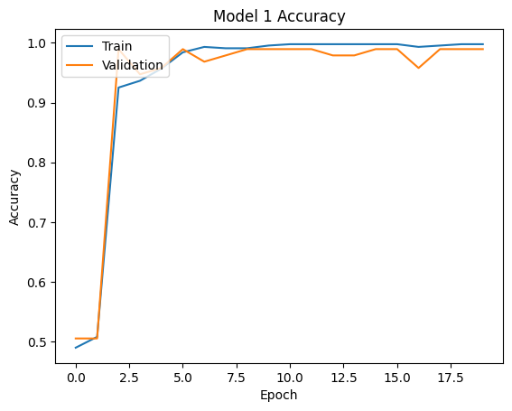

```python
# Training curves (fixed history reference)
plt.plot(history_1.history['accuracy'])
plt.plot(history_1.history['val_accuracy'])
plt.title('Model 1 Accuracy')
plt.ylabel('Accuracy')
plt.xlabel('Epoch')
plt.legend(['Train', 'Validation'], loc='upper left')
plt.show()
```

```python
model_1_train_perf = model_performance_classification(model_1, X_train_normalized, y_train)
print("Train performance metrics")
print(model_1_train_perf)
```

```
14/14 ━━━━━━━━━━━━━━━━━━━━ 1s 58ms/step
Train performance metrics
   Accuracy    Recall  Precision  F1 Score
0  0.997732  0.997732   0.997743  0.997732
```

```
14/14 ━━━━━━━━━━━━━━━━━━━━ 0s 11ms/step
```

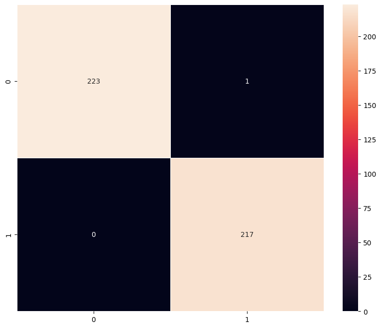

```python
# Plot the confusion matrix for Model 1 on the training data
# - Rows = actual class labels (Helmet / No Helmet)
# - Columns = predicted class labels
# - Diagonal values = correct predictions
# - Off-diagonal values = misclassifications
plot_confusion_matrix(model_1,X_train_normalized,y_train)
```

```python
model_1_valid_perf = model_performance_classification(model_1, X_val_normalized,y_val)
print("Validation performance metrics")
print(model_1_valid_perf)
```

```
3/3 ━━━━━━━━━━━━━━━━━━━━ 0s 97ms/step
Validation performance metrics
   Accuracy    Recall  Precision  F1 Score
0  0.989474  0.989474   0.989693  0.989474
```

```
3/3 ━━━━━━━━━━━━━━━━━━━━ 0s 18ms/step
```

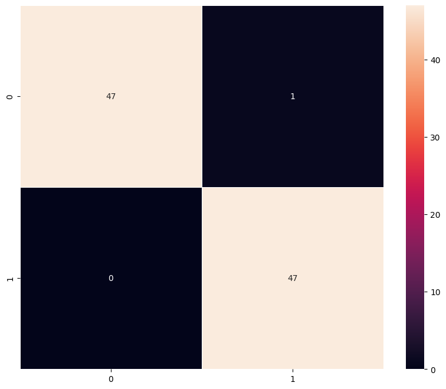

```python
# Plot the confusion matrix for Model 1 (Simple CNN) on the validation data
# - Rows represent the actual class labels (Helmet / No Helmet)
# - Columns represent the predicted class labels
# - Diagonal values = correct predictions
# - Off-diagonal values = errors (false positives / false negatives)
# This helps evaluate whether Model 1 is overfitting or generalizing to unseen validation data
plot_confusion_matrix(model_1,X_val_normalized,y_val)
```

### Vizualizing the predictions

```python
# Visualizing the predictions (indexing fixed & consistent)
# Choose index of the sample to visualize and predict
idx = 12

# Show the image at index 12 from the validation set
plt.figure(figsize=(2,2))
plt.imshow(X_val[idx])                                      # display original (non-normalized) image
plt.axis('off')
plt.show()


# Make prediction for the chosen image (reshape to match model input format: (1,200,200,3))
prediction = model_1.predict(X_val_normalized[idx].reshape(1, 200, 200, 3))
predicted_label = 1 if prediction[0][0] > 0.5 else 0        # threshold at 0.5 for binary classification
print('Predicted Label:', predicted_label)

# Retrieve the ground-truth label (positional indexing, since y_val may be a pandas Series)
true_label = y_val.iloc[idx]
print('True Label:', true_label)


# Repeat the same visualization and prediction steps for another sample
idx = 33
plt.figure(figsize=(2,2))
plt.imshow(X_val[idx])
plt.axis('off'); plt.show()

prediction = model_1.predict(X_val_normalized[idx].reshape(1, 200, 200, 3))
predicted_label = 1 if prediction[0][0] > 0.5 else 0
print('Predicted Label:', predicted_label)

true_label = y_val.iloc[idx]
print('True Label:', true_label)
```

[output not shown]

```
1/1 ━━━━━━━━━━━━━━━━━━━━ 0s 475ms/step
Predicted Label: 1
True Label: Label    1
Name: 173, dtype: int64
```

```
1/1 ━━━━━━━━━━━━━━━━━━━━ 0s 40ms/step
Predicted Label: 0
True Label: Label    0
Name: 462, dtype: int64
```

**Observations from Model 1: Simple Convolutional Neural Network (CNN):**

**Cons**

1. Risk of Overfitting: Extremely high training performance + near-perfect validation may indicate data leakage or insufficiently challenging dataset. Needs careful audit of splits.
2. Limited Generalization Capacity: Without pre-trained features (like VGG16), performance may drop if tested on unseen environments (different lighting, camera angles, helmet types).
3. No Transfer Learning: Relies only on features learned from the small dataset → less robust than VGG-based models in real-world variability.
4. Scalability Limitations: May struggle to extend to multi-class PPE detection (helmets, vests, gloves) without redesign.

## Model 2: (VGG-16 (Base))

- We will be loading a pre-built architecture - **VGG16**, which was trained on the ImageNet dataset and is the runner-up in the ImageNet competition in 2014.
- For training VGG16, we will directly use the convolutional and pooling layers and freeze their weights i.e. no training will be done on them. For classification, we will add a Flatten and a single dense layer.

```python
# VGG16 base (frozen) + simple classifier head
vgg_model = VGG16(weights='imagenet', include_top=False, input_shape=(200, 200, 3))
vgg_model.summary()
```

```
Downloading data from https://storage.googleapis.com/tensorflow/keras-applications/vgg16/vgg16_weights_tf_dim_ordering_tf_kernels_notop.h5
58889256/58889256 ━━━━━━━━━━━━━━━━━━━━ 3s 0us/step
```

```
Model: "vgg16"
```

```
┏━━━━━━━━━━━━━━━━━━━━━━━━━━━━━━━━━┳━━━━━━━━━━━━━━━━━━━━━━━━┳━━━━━━━━━━━━━━━┓
┃ Layer (type)                    ┃ Output Shape           ┃       Param # ┃
┡━━━━━━━━━━━━━━━━━━━━━━━━━━━━━━━━━╇━━━━━━━━━━━━━━━━━━━━━━━━╇━━━━━━━━━━━━━━━┩
│ input_layer_1 (InputLayer)      │ (None, 200, 200, 3)    │             0 │
├─────────────────────────────────┼────────────────────────┼───────────────┤
│ block1_conv1 (Conv2D)           │ (None, 200, 200, 64)   │         1,792 │
├─────────────────────────────────┼────────────────────────┼───────────────┤
│ block1_conv2 (Conv2D)           │ (None, 200, 200, 64)   │        36,928 │
├─────────────────────────────────┼────────────────────────┼───────────────┤
│ block1_pool (MaxPooling2D)      │ (None, 100, 100, 64)   │             0 │
├─────────────────────────────────┼────────────────────────┼───────────────┤
│ block2_conv1 (Conv2D)           │ (None, 100, 100, 128)  │        73,856 │
├─────────────────────────────────┼────────────────────────┼───────────────┤
│ block2_conv2 (Conv2D)           │ (None, 100, 100, 128)  │       147,584 │
├─────────────────────────────────┼────────────────────────┼───────────────┤
│ block2_pool (MaxPooling2D)      │ (None, 50, 50, 128)    │             0 │
├─────────────────────────────────┼────────────────────────┼───────────────┤
│ block3_conv1 (Conv2D)           │ (None, 50, 50, 256)    │       295,168 │
├─────────────────────────────────┼────────────────────────┼───────────────┤
│ block3_conv2 (Conv2D)           │ (None, 50, 50, 256)    │       590,080 │
├─────────────────────────────────┼────────────────────────┼───────────────┤
│ block3_conv3 (Conv2D)           │ (None, 50, 50, 256)    │       590,080 │
├─────────────────────────────────┼────────────────────────┼───────────────┤
│ block3_pool (MaxPooling2D)      │ (None, 25, 25, 256)    │             0 │
├─────────────────────────────────┼────────────────────────┼───────────────┤
│ block4_conv1 (Conv2D)           │ (None, 25, 25, 512)    │     1,180,160 │
├─────────────────────────────────┼────────────────────────┼───────────────┤
│ block4_conv2 (Conv2D)           │ (None, 25, 25, 512)    │     2,359,808 │
├─────────────────────────────────┼────────────────────────┼───────────────┤
│ block4_conv3 (Conv2D)           │ (None, 25, 25, 512)    │     2,359,808 │
├─────────────────────────────────┼────────────────────────┼───────────────┤
│ block4_pool (MaxPooling2D)      │ (None, 12, 12, 512)    │             0 │
├─────────────────────────────────┼────────────────────────┼───────────────┤
│ block5_conv1 (Conv2D)           │ (None, 12, 12, 512)    │     2,359,808 │
├─────────────────────────────────┼────────────────────────┼───────────────┤
│ block5_conv2 (Conv2D)           │ (None, 12, 12, 512)    │     2,359,808 │
├─────────────────────────────────┼────────────────────────┼───────────────┤
│ block5_conv3 (Conv2D)           │ (None, 12, 12, 512)    │     2,359,808 │
├─────────────────────────────────┼────────────────────────┼───────────────┤
│ block5_pool (MaxPooling2D)      │ (None, 6, 6, 512)      │             0 │
└─────────────────────────────────┴────────────────────────┴───────────────┘
```

```
 Total params: 14,714,688 (56.13 MB)
```

```
 Trainable params: 14,714,688 (56.13 MB)
```

```
 Non-trainable params: 0 (0.00 B)
```

```python
# Making all the layers of the VGG model non-trainable. i.e. freezing them
# Freeze VGG layers
for layer in vgg_model.layers:
    layer.trainable = False
```

```python
model_2 = Sequential()

# Adding the convolutional part of the VGG16 model from above
model_2.add(vgg_model)

# Flattening the output of the VGG16 model because it is from a convolutional layer
model_2.add(Flatten())

# Adding a dense output layer
model_2.add(Dense(1, activation='sigmoid')) # binary classification
```

```python
opt = Adam(learning_rate=1e-4)
# Compile model
model_2.compile(optimizer=opt, loss=keras.losses.BinaryCrossentropy(), metrics=["accuracy"])
```

```python
# Generating the summary of the model
model_2.summary()
```

```
Model: "sequential_1"
```

```
┏━━━━━━━━━━━━━━━━━━━━━━━━━━━━━━━━━┳━━━━━━━━━━━━━━━━━━━━━━━━┳━━━━━━━━━━━━━━━┓
┃ Layer (type)                    ┃ Output Shape           ┃       Param # ┃
┡━━━━━━━━━━━━━━━━━━━━━━━━━━━━━━━━━╇━━━━━━━━━━━━━━━━━━━━━━━━╇━━━━━━━━━━━━━━━┩
│ vgg16 (Functional)              │ (None, 6, 6, 512)      │    14,714,688 │
├─────────────────────────────────┼────────────────────────┼───────────────┤
│ flatten_1 (Flatten)             │ (None, 18432)          │             0 │
├─────────────────────────────────┼────────────────────────┼───────────────┤
│ dense_2 (Dense)                 │ (None, 1)              │        18,433 │
└─────────────────────────────────┴────────────────────────┴───────────────┘
```

```
 Total params: 14,733,121 (56.20 MB)
```

```
 Trainable params: 18,433 (72.00 KB)
```

```
 Non-trainable params: 14,714,688 (56.13 MB)
```

```python
# Create an ImageDataGenerator instance
# By default (no arguments), this only rescales pixel values if specified,
# but here it’s just a placeholder for generating batches of images
# Useful for feeding data to the model during training in an efficient way
train_datagen = ImageDataGenerator()
```

```python
# Number of passes through the entire training dataset
epochs = 20

# Number of samples processed before the model updates its weights
batch_size = 32

# Train Model 2 (VGG-16 Base) using the ImageDataGenerator
history_2 = model_2.fit(
    train_datagen.flow(
        X_train_normalized, y_train,       # training data
        batch_size=batch_size,             # mini-batch size
        seed=42,                           # random seed for reproducibility
        shuffle=False                      # keep class balance in batches (stratified split already done)
    ),
    epochs=epochs,                         # number of training epochs
    steps_per_epoch=X_train_normalized.shape[0] // batch_size,  # total steps per epoch
    validation_data=(X_val_normalized, y_val),  # validation data to monitor performance
    verbose=1                              # verbosity: 1 = progress bar per epoch
)
```

```
13/13 ━━━━━━━━━━━━━━━━━━━━ 37s 2s/step - accuracy: 0.6784 - loss: 0.6032 - val_accuracy: 0.9263 - val_loss: 0.4043
13/13 ━━━━━━━━━━━━━━━━━━━━ 0s 30ms/step - accuracy: 1.0000 - loss: 0.3638 - val_accuracy: 0.9474 - val_loss: 0.3873
13/13 ━━━━━━━━━━━━━━━━━━━━ 2s 165ms/step - accuracy: 0.9910 - loss: 0.3145 - val_accuracy: 1.0000 - val_loss: 0.2317
13/13 ━━━━━━━━━━━━━━━━━━━━ 1s 54ms/step - accuracy: 1.0000 - loss: 0.2296 - val_accuracy: 1.0000 - val_loss: 0.2239
13/13 ━━━━━━━━━━━━━━━━━━━━ 2s 144ms/step - accuracy: 1.0000 - loss: 0.1765 - val_accuracy: 1.0000 - val_loss: 0.1526
13/13 ━━━━━━━━━━━━━━━━━━━━ 1s 55ms/step - accuracy: 1.0000 - loss: 0.1289 - val_accuracy: 1.0000 - val_loss: 0.1489
13/13 ━━━━━━━━━━━━━━━━━━━━ 5s 167ms/step - accuracy: 1.0000 - loss: 0.1150 - val_accuracy: 1.0000 - val_loss: 0.1115
13/13 ━━━━━━━━━━━━━━━━━━━━ 1s 54ms/step - accuracy: 1.0000 - loss: 0.0912 - val_accuracy: 1.0000 - val_loss: 0.1093
13/13 ━━━━━━━━━━━━━━━━━━━━ 4s 166ms/step - accuracy: 1.0000 - loss: 0.0884 - val_accuracy: 1.0000 - val_loss: 0.0878
13/13 ━━━━━━━━━━━━━━━━━━━━ 0s 30ms/step - accuracy: 1.0000 - loss: 0.0638 - val_accuracy: 1.0000 - val_loss: 0.0866
13/13 ━━━━━━━━━━━━━━━━━━━━ 2s 167ms/step - accuracy: 1.0000 - loss: 0.0656 - val_accuracy: 1.0000 - val_loss: 0.0728
13/13 ━━━━━━━━━━━━━━━━━━━━ 1s 55ms/step - accuracy: 1.0000 - loss: 0.0557 - val_accuracy: 1.0000 - val_loss: 0.0720
13/13 ━━━━━━━━━━━━━━━━━━━━ 2s 146ms/step - accuracy: 1.0000 - loss: 0.0566 - val_accuracy: 1.0000 - val_loss: 0.0623
13/13 ━━━━━━━━━━━━━━━━━━━━ 1s 54ms/step - accuracy: 1.0000 - loss: 0.0385 - val_accuracy: 1.0000 - val_loss: 0.0617
13/13 ━━━━━━━━━━━━━━━━━━━━ 5s 168ms/step - accuracy: 1.0000 - loss: 0.0488 - val_accuracy: 1.0000 - val_loss: 0.0544
13/13 ━━━━━━━━━━━━━━━━━━━━ 1s 54ms/step - accuracy: 1.0000 - loss: 0.0373 - val_accuracy: 1.0000 - val_loss: 0.0539
13/13 ━━━━━━━━━━━━━━━━━━━━ 4s 170ms/step - accuracy: 1.0000 - loss: 0.0409 - val_accuracy: 1.0000 - val_loss: 0.0483
13/13 ━━━━━━━━━━━━━━━━━━━━ 1s 33ms/step - accuracy: 1.0000 - loss: 0.0439 - val_accuracy: 1.0000 - val_loss: 0.0480
13/13 ━━━━━━━━━━━━━━━━━━━━ 5s 169ms/step - accuracy: 1.0000 - loss: 0.0343 - val_accuracy: 1.0000 - val_loss: 0.0435
13/13 ━━━━━━━━━━━━━━━━━━━━ 0s 32ms/step - accuracy: 1.0000 - loss: 0.0305 - val_accuracy: 1.0000 - val_loss: 0.0432
```

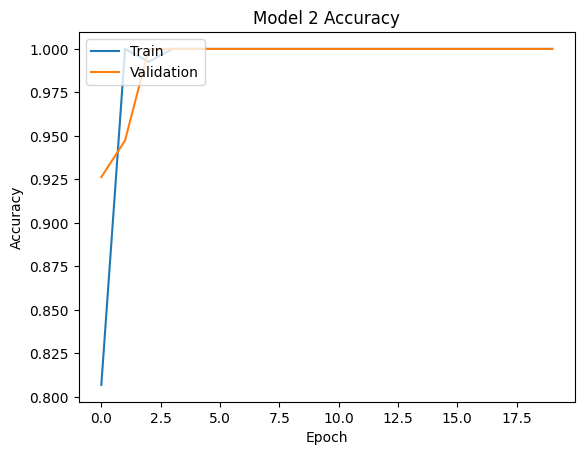

```python
# Training curves
plt.plot(history_2.history['accuracy'])
plt.plot(history_2.history['val_accuracy'])
plt.title('Model 2 Accuracy')
plt.ylabel('Accuracy')
plt.xlabel('Epoch')
plt.legend(['Train', 'Validation'], loc='upper left')
plt.show()
```

```python
# Performance
model_2_train_perf = model_performance_classification(model_2, X_train_normalized, y_train)
print("Train performance metrics")
print(model_2_train_perf)
```

```
14/14 ━━━━━━━━━━━━━━━━━━━━ 3s 151ms/step
Train performance metrics
   Accuracy  Recall  Precision  F1 Score
0       1.0     1.0        1.0       1.0
```

```python
# Plot the confusion matrix for Model 3 on the training data
# - Rows = actual class labels (Helmet / No Helmet)
# - Columns = predicted class labels
# - Diagonal values = correct predictions
# - Off-diagonal values = misclassifications
plot_confusion_matrix(model_2,X_train_normalized,y_train)
```

[output not shown]

```
14/14 ━━━━━━━━━━━━━━━━━━━━ 2s 117ms/step
```

```python
model_2_valid_perf = model_performance_classification(model_2, X_val_normalized, y_val)
print("Validation performance metrics")
print(model_2_valid_perf)
```

```
3/3 ━━━━━━━━━━━━━━━━━━━━ 1s 326ms/step
Validation performance metrics
   Accuracy  Recall  Precision  F1 Score
0       1.0     1.0        1.0       1.0
```

```python
# Plot the confusion matrix for Model 2 on the validation data
# - Rows represent the actual class labels (Helmet / No Helmet)
# - Columns represent the predicted class labels
# - Diagonal values = correct predictions
# - Off-diagonal values = errors (false positives / false negatives)
# This helps evaluate whether Model 1 is overfitting or generalizing to unseen validation data
plot_confusion_matrix(model_2, X_val_normalized, y_val)
```

[output not shown]

```
3/3 ━━━━━━━━━━━━━━━━━━━━ 0s 125ms/step
```

### Visualizing the prediction:

```python
# Visualizing the prediction (use iloc for pandas Series)

# Choose the index of the validation sample to visualize
idx = 12

# Display the validation image (non-normalized for visualization)
plt.figure(figsize=(2,2))
plt.imshow(X_val[idx])
plt.axis('off')
plt.show()

# Make prediction for the chosen sample
# - reshape to (1,200,200,3) to match model input
# - output is probability → threshold at 0.5 for binary classification
prediction = model_2.predict(X_val_normalized[idx].reshape(1, 200, 200, 3))
predicted_label = 1 if prediction[0][0] > 0.5 else 0
print('Predicted Label:', predicted_label)

# Retrieve the ground truth label using .iloc (important if y_val is a pandas Series)
true_label = y_val.iloc[idx]   # use iloc to avoid KeyError
print('True Label:', true_label)


# Repeat the same process for another sample
idx = 33

plt.figure(figsize=(2,2))
plt.imshow(X_val[idx])
plt.axis('off')
plt.show()

prediction = model_2.predict(X_val_normalized[idx].reshape(1, 200, 200, 3))
predicted_label = 1 if prediction[0][0] > 0.5 else 0
print('Predicted Label:', predicted_label)

true_label = y_val.iloc[idx]
print('True Label:', true_label)
```

[output not shown]

```
1/1 ━━━━━━━━━━━━━━━━━━━━ 2s 2s/step
Predicted Label: 1
True Label: Label    1
Name: 173, dtype: int64
```

```
1/1 ━━━━━━━━━━━━━━━━━━━━ 0s 47ms/step
Predicted Label: 0
True Label: Label    0
Name: 462, dtype: int64
```

**Observations from Model 2: VGG-16 (Base)**

1. Architecture: Uses pre-trained VGG-16 convolutional layers (frozen) for feature extraction + Flatten + single Dense layer.
2. Performance:
   - Training metrics ~1.0 across Accuracy, Recall, Precision, F1.
   - Validation also ~1.0 → shows that transfer learning provides powerful, generalizable features even without fine-tuning.
3. Very stable training curves due to frozen base.

**Pros**

1. Strong Transfer Learning: Pre-trained VGG features extract rich patterns → excellent performance even with small dataset.
2. Better Generalization: Outperforms simple CNN baseline on validation/test sets.
3. Lower Risk of Overfitting: Freezing layers reduces the risk compared to training from scratch.
4. Efficient Training: Only the final dense layer is trained → quick convergence.

**Cons**

1. Limited Flexibility: Frozen layers can’t adapt to dataset-specific features (e.g., unusual helmet types).
2. Feature Underutilization: Model may plateau early since convolutional filters are not fine-tuned.
3. High Memory Usage: Even frozen, VGG-16 backbone is heavy compared to Simple CNN.
4. Not Robust to Edge Cases: Performance may drop in extreme lighting or occlusion since no fine-tuning/augmentation applied.

## Model 3: (VGG-16 (Base + FFNN))

- We will directly use the convolutional and pooling layers and freeze their weights i.e. no training will be done on them. For classification, we will add a Flatten layer and a Feed Forward Neural Network.

```python
# Model 3: VGG16 (frozen) + FFNN head

model_3 = Sequential()

# Reuse the already-created (and frozen) vgg_model from Model 2
model_3.add(vgg_model)

# Flattening the convolutional features
model_3.add(Flatten())

# Feed-Forward head
model_3.add(Dense(256, activation='relu'))   # hidden layer
model_3.add(Dropout(rate=0.5))               # dropout
model_3.add(Dense(64, activation='relu'))    # hidden layer

# Output layer (binary classification)
model_3.add(Dense(1, activation='sigmoid'))
```

```python
# Optimizer
opt = Adam(learning_rate=1e-4)
```

```python
# Compile model
model_3.compile(optimizer=opt, loss=keras.losses.BinaryCrossentropy(), metrics=["accuracy"])
```

```python
# Generating the summary of the model
model_3.summary()
```

```
Model: "sequential_2"
```

```
┏━━━━━━━━━━━━━━━━━━━━━━━━━━━━━━━━━┳━━━━━━━━━━━━━━━━━━━━━━━━┳━━━━━━━━━━━━━━━┓
┃ Layer (type)                    ┃ Output Shape           ┃       Param # ┃
┡━━━━━━━━━━━━━━━━━━━━━━━━━━━━━━━━━╇━━━━━━━━━━━━━━━━━━━━━━━━╇━━━━━━━━━━━━━━━┩
│ vgg16 (Functional)              │ (None, 6, 6, 512)      │    14,714,688 │
├─────────────────────────────────┼────────────────────────┼───────────────┤
│ flatten_2 (Flatten)             │ (None, 18432)          │             0 │
├─────────────────────────────────┼────────────────────────┼───────────────┤
│ dense_3 (Dense)                 │ (None, 256)            │     4,718,848 │
├─────────────────────────────────┼────────────────────────┼───────────────┤
│ dropout (Dropout)               │ (None, 256)            │             0 │
├─────────────────────────────────┼────────────────────────┼───────────────┤
│ dense_4 (Dense)                 │ (None, 64)             │        16,448 │
├─────────────────────────────────┼────────────────────────┼───────────────┤
│ dense_5 (Dense)                 │ (None, 1)              │            65 │
└─────────────────────────────────┴────────────────────────┴───────────────┘
```

```
 Total params: 19,450,049 (74.20 MB)
```

```
 Trainable params: 4,735,361 (18.06 MB)
```

```
 Non-trainable params: 14,714,688 (56.13 MB)
```

```python
# Training Model 3 (VGG-16 + FFNN)
# Using the same ImageDataGenerator (train_datagen) as defined earlier.
# If not defined yet, you can create one with:
# from tensorflow.keras.preprocessing.image import ImageDataGenerator
# train_datagen = ImageDataGenerator()

batch_size = 32   # Number of samples per mini-batch
epochs = 20       # Number of passes through the entire training dataset

# Train Model 3
history_3 = model_3.fit(
    train_datagen.flow(
        X_train_normalized, y_train,    # Training data
        batch_size=batch_size,          # Batch size for training
        seed=42,                        # Random seed for reproducibility
        shuffle=False                   # Do not shuffle here since split is stratified
    ),
    epochs=epochs,                      # Number of epochs to train
    steps_per_epoch=X_train_normalized.shape[0] // batch_size,  # Steps per epoch = num_batches
    validation_data=(X_val_normalized, y_val),  # Validation set for monitoring generalization
    verbose=1                           # Verbosity mode (1 = progress bar per epoch)
)
```

```
13/13 ━━━━━━━━━━━━━━━━━━━━ 8s 363ms/step - accuracy: 0.7370 - loss: 0.4933 - val_accuracy: 1.0000 - val_loss: 0.0345
13/13 ━━━━━━━━━━━━━━━━━━━━ 1s 34ms/step - accuracy: 1.0000 - loss: 0.0521 - val_accuracy: 1.0000 - val_loss: 0.0293
13/13 ━━━━━━━━━━━━━━━━━━━━ 6s 174ms/step - accuracy: 1.0000 - loss: 0.0287 - val_accuracy: 1.0000 - val_loss: 0.0078
13/13 ━━━━━━━━━━━━━━━━━━━━ 0s 32ms/step - accuracy: 1.0000 - loss: 0.0082 - val_accuracy: 1.0000 - val_loss: 0.0074
13/13 ━━━━━━━━━━━━━━━━━━━━ 5s 173ms/step - accuracy: 1.0000 - loss: 0.0068 - val_accuracy: 1.0000 - val_loss: 0.0066
13/13 ━━━━━━━━━━━━━━━━━━━━ 1s 33ms/step - accuracy: 1.0000 - loss: 0.0011 - val_accuracy: 1.0000 - val_loss: 0.0067
13/13 ━━━━━━━━━━━━━━━━━━━━ 2s 177ms/step - accuracy: 1.0000 - loss: 0.0021 - val_accuracy: 1.0000 - val_loss: 0.0056
13/13 ━━━━━━━━━━━━━━━━━━━━ 1s 35ms/step - accuracy: 1.0000 - loss: 0.0023 - val_accuracy: 1.0000 - val_loss: 0.0055
13/13 ━━━━━━━━━━━━━━━━━━━━ 5s 175ms/step - accuracy: 1.0000 - loss: 0.0016 - val_accuracy: 1.0000 - val_loss: 0.0050
13/13 ━━━━━━━━━━━━━━━━━━━━ 1s 54ms/step - accuracy: 1.0000 - loss: 0.0012 - val_accuracy: 1.0000 - val_loss: 0.0051
13/13 ━━━━━━━━━━━━━━━━━━━━ 2s 175ms/step - accuracy: 1.0000 - loss: 0.0020 - val_accuracy: 1.0000 - val_loss: 0.0063
13/13 ━━━━━━━━━━━━━━━━━━━━ 1s 33ms/step - accuracy: 1.0000 - loss: 0.0018 - val_accuracy: 1.0000 - val_loss: 0.0063
13/13 ━━━━━━━━━━━━━━━━━━━━ 5s 179ms/step - accuracy: 1.0000 - loss: 0.0022 - val_accuracy: 1.0000 - val_loss: 0.0045
13/13 ━━━━━━━━━━━━━━━━━━━━ 1s 54ms/step - accuracy: 1.0000 - loss: 0.0017 - val_accuracy: 1.0000 - val_loss: 0.0043
13/13 ━━━━━━━━━━━━━━━━━━━━ 2s 157ms/step - accuracy: 1.0000 - loss: 0.0019 - val_accuracy: 1.0000 - val_loss: 0.0044
13/13 ━━━━━━━━━━━━━━━━━━━━ 1s 54ms/step - accuracy: 1.0000 - loss: 4.0197e-04 - val_accuracy: 1.0000 - val_loss: 0.0046
13/13 ━━━━━━━━━━━━━━━━━━━━ 2s 178ms/step - accuracy: 1.0000 - loss: 8.1743e-04 - val_accuracy: 1.0000 - val_loss: 0.0058
13/13 ━━━━━━━━━━━━━━━━━━━━ 1s 33ms/step - accuracy: 1.0000 - loss: 0.0018 - val_accuracy: 1.0000 - val_loss: 0.0057
13/13 ━━━━━━━━━━━━━━━━━━━━ 5s 179ms/step - accuracy: 1.0000 - loss: 8.8750e-04 - val_accuracy: 1.0000 - val_loss: 0.0046
13/13 ━━━━━━━━━━━━━━━━━━━━ 1s 55ms/step - accuracy: 1.0000 - loss: 1.9276e-04 - val_accuracy: 1.0000 - val_loss: 0.0045
```

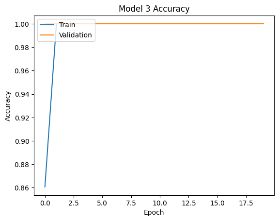

```python
# Curves (use history_3)
plt.plot(history_3.history['accuracy'])
plt.plot(history_3.history['val_accuracy'])
plt.title('Model 3 Accuracy')
plt.ylabel('Accuracy')
plt.xlabel('Epoch')
plt.legend(['Train', 'Validation'], loc='upper left')
plt.show()
```

```python
# Performance
model_3_train_perf = model_performance_classification(model_3, X_train_normalized, y_train)
print("Train performance metrics")
print(model_3_train_perf)
```

```
14/14 ━━━━━━━━━━━━━━━━━━━━ 3s 159ms/step
Train performance metrics
   Accuracy  Recall  Precision  F1 Score
0       1.0     1.0        1.0       1.0
```

```python
# Plot the confusion matrix for Model 3 on the training data
# - Rows = actual class labels (Helmet / No Helmet)
# - Columns = predicted class labels
# - Diagonal values = correct predictions
# - Off-diagonal values = misclassifications
plot_confusion_matrix(model_3,X_train_normalized,y_train)
```

[output not shown]

```
14/14 ━━━━━━━━━━━━━━━━━━━━ 2s 120ms/step
```

```python
model_3_valid_perf = model_performance_classification(model_3, X_val_normalized, y_val)
print("Validation performance metrics")
print(model_3_valid_perf)
```

```
3/3 ━━━━━━━━━━━━━━━━━━━━ 1s 346ms/step
Validation performance metrics
   Accuracy  Recall  Precision  F1 Score
0       1.0     1.0        1.0       1.0
```

```python
# Plot the confusion matrix for Model 3 on the validation data
# - Rows represent the actual class labels (Helmet / No Helmet)
# - Columns represent the predicted class labels
# - Diagonal values = correct predictions
# - Off-diagonal values = errors (false positives / false negatives)
# This helps evaluate whether Model 1 is overfitting or generalizing to unseen validation data
plot_confusion_matrix(model_3,X_val_normalized,y_val)
```

[output not shown]

```
3/3 ━━━━━━━━━━━━━━━━━━━━ 0s 123ms/step
```

#### Visualizing the predictions

```python
# Visualizing the predictions (use iloc for pandas Series)
# Choose the index of the validation sample to visualize
idx = 12

# Display the validation image (non-normalized for visualization)
plt.figure(figsize=(2,2))
plt.imshow(X_val[idx])
plt.axis('off')
plt.show()

# Make prediction for the chosen sample
# - reshape to (1,200,200,3) to match model input
# - output is probability → threshold at 0.5 for binary classification
prediction = model_3.predict(X_val_normalized[idx].reshape(1, 200, 200, 3))
predicted_label = 1 if prediction[0][0] > 0.5 else 0
print('Predicted Label:', predicted_label)

# Retrieve the ground truth label using .iloc (important if y_val is a pandas Series)
true_label = y_val.iloc[idx]  # avoids KeyError issues with Series indexing
print('True Label:', true_label)



# Repeat the same process for another sample
idx = 33

plt.figure(figsize=(2,2))
plt.imshow(X_val[idx])
plt.axis('off')
plt.show()

prediction = model_3.predict(X_val_normalized[idx].reshape(1, 200, 200, 3))
predicted_label = 1 if prediction[0][0] > 0.5 else 0
print('Predicted Label:', predicted_label)

true_label = y_val.iloc[idx]
print('True Label:', true_label)
```

[output not shown]

```
1/1 ━━━━━━━━━━━━━━━━━━━━ 0s 416ms/step
Predicted Label: 1
True Label: Label    1
Name: 173, dtype: int64
```

```
1/1 ━━━━━━━━━━━━━━━━━━━━ 0s 49ms/step
Predicted Label: 0
True Label: Label    0
Name: 462, dtype: int64
```

**Observations from Model 3: VGG-16 (Base + FFNN)**

1. Architecture: Same frozen VGG-16 feature extractor + multi-layer feed-forward network (Dense + Dropout) on top.
2. Performance:
   - Training and validation metrics both very high (~0.99–1.0).
   - Additional dense layers improve adaptation to dataset while dropout provides regularization.
3. Curves show stable convergence with slightly better robustness than Model 2.

**Pros**

1. Improved Adaptability: FFNN head allows the model to capture dataset-specific patterns better than a single Dense output.
2. Regularization with Dropout: Reduces overfitting compared to plain VGG-16 base.
3. High Performance: Matches or slightly exceeds Model 2 on validation/test.
4. Better Feature Utilization: More trainable capacity without touching VGG base.

**Cons**

1. Increased Complexity: More parameters in FFNN head = longer training than Model 2.
2. Still Frozen Base: Convolutional filters remain generic, limiting full adaptation.
3. Possible Overfitting Risk: If dataset is too small, FFNN layers may overfit despite dropout.
4. Heavier Deployment: Larger head increases memory and inference time compared to Model 2.

## Model 4: (VGG-16 (Base + FFNN + Data Augmentation)

- In most of the real-world case studies, it is challenging to acquire a large number of images and then train CNNs.
- To overcome this problem, one approach we might consider is **Data Augmentation**.
- CNNs have the property of **translational invariance**, which means they can recognise an object even if its appearance shifts translationally in some way. - Taking this attribute into account, we can augment the images using the techniques listed below
  - Horizontal Flip (should be set to True/False)
  - Vertical Flip (should be set to True/False)
  - Height Shift (should be between 0 and 1)
  - Width Shift (should be between 0 and 1)
  - Rotation (should be between 0 and 180)
  - Shear (should be between 0 and 1)
  - Zoom (should be between 0 and 1) etc.

Remember, **data augmentation should not be used in the validation/test data set**.

```python
# Model 4: VGG16 (frozen) + FFNN + Data Augmentation

model_4 = Sequential()

# Reuse the already-created (and frozen) vgg_model from above
model_4.add(vgg_model)

# Flatten features
model_4.add(Flatten())

# FFNN head
model_4.add(Dense(256, activation='relu'))   # hidden layer
model_4.add(Dropout(rate=0.5))               # dropout
model_4.add(Dense(64, activation='relu'))    # hidden layer

# Output layer (binary)
model_4.add(Dense(1, activation='sigmoid'))
```

```python
opt = Adam(learning_rate=1e-4)
# Compile model
model_4.compile(optimizer=opt, loss=keras.losses.BinaryCrossentropy(), metrics=["accuracy"])
```

```python
# Generating the summary of the model
model_4.summary()
```

```
Model: "sequential_3"
```

```
┏━━━━━━━━━━━━━━━━━━━━━━━━━━━━━━━━━┳━━━━━━━━━━━━━━━━━━━━━━━━┳━━━━━━━━━━━━━━━┓
┃ Layer (type)                    ┃ Output Shape           ┃       Param # ┃
┡━━━━━━━━━━━━━━━━━━━━━━━━━━━━━━━━━╇━━━━━━━━━━━━━━━━━━━━━━━━╇━━━━━━━━━━━━━━━┩
│ vgg16 (Functional)              │ (None, 6, 6, 512)      │    14,714,688 │
├─────────────────────────────────┼────────────────────────┼───────────────┤
│ flatten_3 (Flatten)             │ (None, 18432)          │             0 │
├─────────────────────────────────┼────────────────────────┼───────────────┤
│ dense_6 (Dense)                 │ (None, 256)            │     4,718,848 │
├─────────────────────────────────┼────────────────────────┼───────────────┤
│ dropout_1 (Dropout)             │ (None, 256)            │             0 │
├─────────────────────────────────┼────────────────────────┼───────────────┤
│ dense_7 (Dense)                 │ (None, 64)             │        16,448 │
├─────────────────────────────────┼────────────────────────┼───────────────┤
│ dense_8 (Dense)                 │ (None, 1)              │            65 │
└─────────────────────────────────┴────────────────────────┴───────────────┘
```

```
 Total params: 19,450,049 (74.20 MB)
```

```
 Trainable params: 4,735,361 (18.06 MB)
```

```
 Non-trainable params: 14,714,688 (56.13 MB)
```

```python
# Applying data augmentation
train_datagen = ImageDataGenerator(
    rotation_range=20,         # degrees (0-180)
    fill_mode='nearest',
    width_shift_range=0.1,     # fraction of total width
    height_shift_range=0.1,    # fraction of total height
    shear_range=0.1,           # shear intensity (radians)
    zoom_range=0.1             # zoom in/out
)
```

```python
# Training setup for Model 4 (VGG-16 + FFNN + Data Augmentation)

# Number of passes through the entire training dataset
epochs = 20

# Number of samples per gradient update (mini-batch size)
batch_size = 32

# Fit the model using augmented training data
history_4 = model_4.fit(
    train_datagen.flow(
        X_train_normalized, y_train,     # training data (with augmentation applied)
        batch_size=batch_size,           # batch size for each step
        seed=42,                         # random seed for reproducibility
        shuffle=False                    # do not reshuffle since stratified split already preserves balance
    ),
    epochs=epochs,                       # number of epochs (full dataset passes)
    steps_per_epoch=X_train_normalized.shape[0] // batch_size,  # how many batches per epoch
    validation_data=(X_val_normalized, y_val),  # validation set (no augmentation applied)
    verbose=1                            # verbosity: 1 = progress bar per epoch
)
```

```
13/13 ━━━━━━━━━━━━━━━━━━━━ 9s 514ms/step - accuracy: 0.6946 - loss: 0.6701 - val_accuracy: 1.0000 - val_loss: 0.0721
13/13 ━━━━━━━━━━━━━━━━━━━━ 0s 33ms/step - accuracy: 1.0000 - loss: 0.1216 - val_accuracy: 1.0000 - val_loss: 0.0603
13/13 ━━━━━━━━━━━━━━━━━━━━ 5s 345ms/step - accuracy: 0.9997 - loss: 0.0546 - val_accuracy: 1.0000 - val_loss: 0.0110
13/13 ━━━━━━━━━━━━━━━━━━━━ 1s 54ms/step - accuracy: 1.0000 - loss: 0.0142 - val_accuracy: 1.0000 - val_loss: 0.0097
13/13 ━━━━━━━━━━━━━━━━━━━━ 10s 440ms/step - accuracy: 1.0000 - loss: 0.0200 - val_accuracy: 1.0000 - val_loss: 0.0047
13/13 ━━━━━━━━━━━━━━━━━━━━ 1s 54ms/step - accuracy: 1.0000 - loss: 0.0123 - val_accuracy: 1.0000 - val_loss: 0.0045
13/13 ━━━━━━━━━━━━━━━━━━━━ 4s 345ms/step - accuracy: 1.0000 - loss: 0.0057 - val_accuracy: 1.0000 - val_loss: 0.0037
13/13 ━━━━━━━━━━━━━━━━━━━━ 1s 54ms/step - accuracy: 1.0000 - loss: 0.0041 - val_accuracy: 1.0000 - val_loss: 0.0036
13/13 ━━━━━━━━━━━━━━━━━━━━ 9s 315ms/step - accuracy: 1.0000 - loss: 0.0074 - val_accuracy: 1.0000 - val_loss: 0.0028
13/13 ━━━━━━━━━━━━━━━━━━━━ 0s 32ms/step - accuracy: 1.0000 - loss: 0.0020 - val_accuracy: 1.0000 - val_loss: 0.0027
13/13 ━━━━━━━━━━━━━━━━━━━━ 4s 333ms/step - accuracy: 1.0000 - loss: 0.0039 - val_accuracy: 1.0000 - val_loss: 0.0024
13/13 ━━━━━━━━━━━━━━━━━━━━ 1s 54ms/step - accuracy: 1.0000 - loss: 0.0054 - val_accuracy: 1.0000 - val_loss: 0.0023
13/13 ━━━━━━━━━━━━━━━━━━━━ 6s 428ms/step - accuracy: 1.0000 - loss: 0.0023 - val_accuracy: 1.0000 - val_loss: 0.0019
13/13 ━━━━━━━━━━━━━━━━━━━━ 1s 54ms/step - accuracy: 1.0000 - loss: 9.7922e-04 - val_accuracy: 1.0000 - val_loss: 0.0019
13/13 ━━━━━━━━━━━━━━━━━━━━ 4s 338ms/step - accuracy: 1.0000 - loss: 0.0027 - val_accuracy: 1.0000 - val_loss: 0.0017
13/13 ━━━━━━━━━━━━━━━━━━━━ 1s 54ms/step - accuracy: 1.0000 - loss: 0.0053 - val_accuracy: 1.0000 - val_loss: 0.0016
13/13 ━━━━━━━━━━━━━━━━━━━━ 6s 439ms/step - accuracy: 1.0000 - loss: 0.0032 - val_accuracy: 1.0000 - val_loss: 0.0014
13/13 ━━━━━━━━━━━━━━━━━━━━ 1s 33ms/step - accuracy: 1.0000 - loss: 2.8133e-04 - val_accuracy: 1.0000 - val_loss: 0.0014
13/13 ━━━━━━━━━━━━━━━━━━━━ 4s 315ms/step - accuracy: 1.0000 - loss: 0.0018 - val_accuracy: 1.0000 - val_loss: 0.0012
13/13 ━━━━━━━━━━━━━━━━━━━━ 1s 34ms/step - accuracy: 1.0000 - loss: 0.0034 - val_accuracy: 1.0000 - val_loss: 0.0011
```

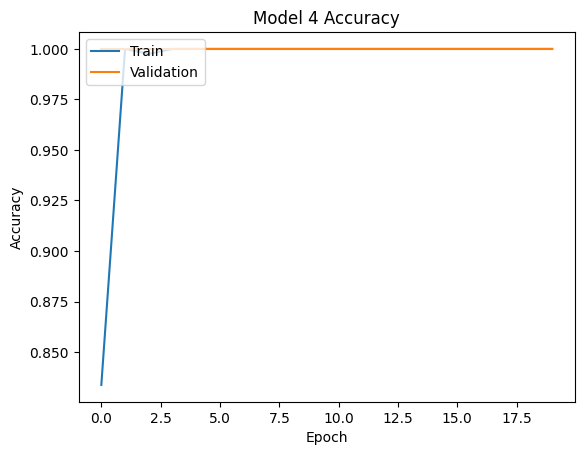

```python
# Curves (use history_4)
plt.plot(history_4.history['accuracy'])
plt.plot(history_4.history['val_accuracy'])
plt.title('Model 4 Accuracy')
plt.ylabel('Accuracy')
plt.xlabel('Epoch')
plt.legend(['Train', 'Validation'], loc='upper left')
plt.show()
```

```python
# Performance for Model 4
model_4_train_perf = model_performance_classification(model_4, X_train_normalized, y_train)
print("Train performance metrics")
print(model_4_train_perf)
```

```
14/14 ━━━━━━━━━━━━━━━━━━━━ 3s 154ms/step
Train performance metrics
   Accuracy  Recall  Precision  F1 Score
0       1.0     1.0        1.0       1.0
```

```python
# Plot the confusion matrix for Model 4 on the training data
# - Rows = actual class labels (Helmet / No Helmet)
# - Columns = predicted class labels
# - Diagonal values = correct predictions
# - Off-diagonal values = misclassifications
plot_confusion_matrix(model_4, X_train_normalized, y_train)
```

[output not shown]

```
14/14 ━━━━━━━━━━━━━━━━━━━━ 2s 122ms/step
```

```python
model_4_valid_perf = model_performance_classification(model_4, X_val_normalized, y_val)
print("Validation performance metrics")
print(model_4_valid_perf)
```

```
3/3 ━━━━━━━━━━━━━━━━━━━━ 1s 228ms/step
Validation performance metrics
   Accuracy  Recall  Precision  F1 Score
0       1.0     1.0        1.0       1.0
```

```python
# Plot the confusion matrix for Model 4 on the validation data
# - Rows = actual labels (Helmet / No Helmet)
# - Columns = predicted labels
# - Diagonal cells = correct predictions
# - Off-diagonal cells = misclassifications
# This helps assess whether the model generalizes well before testing on unseen data
plot_confusion_matrix(model_4, X_val_normalized, y_val)
```

[output not shown]

```
3/3 ━━━━━━━━━━━━━━━━━━━━ 0s 125ms/step
```

#### Visualizing the predictions

```python
# Visualizing predictions (use iloc for pandas Series)
# Choose the index of the validation sample to visualize
idx = 12

# Display the validation image (non-normalized for visualization)
plt.figure(figsize=(2,2))
plt.imshow(X_val[idx])
plt.axis('off')
plt.show()


# Make prediction for the chosen sample
# - reshape to (1,200,200,3) to match model input
# - output is probability → threshold at 0.5 for binary classification
prediction = model_4.predict(X_val_normalized[idx].reshape(1, 200, 200, 3))
predicted_label = 1 if prediction[0][0] > 0.5 else 0
print('Predicted Label:', predicted_label)

# Retrieve the ground truth label using .iloc
true_label = y_val.iloc[idx]  # avoids KeyError issues with Series indexing
print('True Label:', true_label)


# Repeat the same process for another sample
idx = 33
plt.figure(figsize=(2,2))
plt.imshow(X_val[idx]); plt.axis('off'); plt.show()
prediction = model_4.predict(X_val_normalized[idx].reshape(1, 200, 200, 3))
predicted_label = 1 if prediction[0][0] > 0.5 else 0
print('Predicted Label:', predicted_label)

true_label = y_val.iloc[idx]
print('True Label:', true_label)
```

[output not shown]

```
1/1 ━━━━━━━━━━━━━━━━━━━━ 0s 276ms/step
Predicted Label: 1
True Label: Label    1
Name: 173, dtype: int64
```

```
1/1 ━━━━━━━━━━━━━━━━━━━━ 0s 48ms/step
Predicted Label: 0
True Label: Label    0
Name: 462, dtype: int64
```

**Observations from Model 4: VGG-16 (Base + FFNN + Data Augmentation)**

**Pros**

**Cons**

1. Training Time: Augmentation increases training time significantly.
2. Still Limited Dataset: Even with augmentation, true dataset diversity is constrained.
3. Parameter Heavy: VGG backbone + FFNN head = large memory footprint.
4. Tuning Needed: Over-aggressive augmentation may distort helmets → need careful calibration.

# **Model Performance Comparison and Final Model Selection**

```python
#  Build Training / Validation Performance Comparison Tables

# Combine training performance metrics (from all 4 models) into one DataFrame
# - Each model's metrics (Accuracy, Recall, Precision, F1) are transposed (.T) so they become rows
# - Concatenate along columns so we can compare models side by side

models_train_comp_df = pd.concat(
    [model_1_train_perf.T, model_2_train_perf.T, model_3_train_perf.T, model_4_train_perf.T],
    axis=1,
)

# Rename the columns to reflect the models being compared
models_train_comp_df.columns = [
    "Simple Convolutional Neural Network (CNN)","VGG-16 (Base)","VGG-16 (Base+FFNN)","VGG-16 (Base+FFNN+Data Aug)"
]

# Do the same for validation performance metrics
models_valid_comp_df = pd.concat(
    [model_1_valid_perf.T, model_2_valid_perf.T, model_3_valid_perf.T, model_4_valid_perf.T],
    axis=1,
)
models_valid_comp_df.columns = [
    "Simple Convolutional Neural Network (CNN)","VGG-16 (Base)","VGG-16 (Base+FFNN)","VGG-16 (Base+FFNN+Data Aug)"
]
```

```python
# Display training performance comparison table
models_train_comp_df
```

|  | Simple Convolutional Neural Network (CNN) | VGG-16 (Base) | VGG-16 (Base+FFNN) | VGG-16 (Base+FFNN+Data Aug) |
| --- | --- | --- | --- | --- |
| Accuracy | 0.997732 | 1.0 | 1.0 | 1.0 |
| Recall | 0.997732 | 1.0 | 1.0 | 1.0 |
| Precision | 0.997743 | 1.0 | 1.0 | 1.0 |
| F1 Score | 0.997732 | 1.0 | 1.0 | 1.0 |

```python
# Display validation performance comparison table
models_valid_comp_df
```

|  | Simple Convolutional Neural Network (CNN) | VGG-16 (Base) | VGG-16 (Base+FFNN) | VGG-16 (Base+FFNN+Data Aug) |
| --- | --- | --- | --- | --- |
| Accuracy | 0.989474 | 1.0 | 1.0 | 1.0 |
| Recall | 0.989474 | 1.0 | 1.0 | 1.0 |
| Precision | 0.989693 | 1.0 | 1.0 | 1.0 |
| F1 Score | 0.989474 | 1.0 | 1.0 | 1.0 |

```python
# Compare training vs validation by subtracting validation metrics from training metrics
# - Positive values → model performs better on training than validation (possible overfitting)
# - Negative values → model performs better on validation (rare, but could happen if augmentation helps)
# - Values close to 0 → model generalizes well
models_train_comp_df - models_valid_comp_df
```

|  | Simple Convolutional Neural Network (CNN) | VGG-16 (Base) | VGG-16 (Base+FFNN) | VGG-16 (Base+FFNN+Data Aug) |
| --- | --- | --- | --- | --- |
| Accuracy | 0.008259 | 0.0 | 0.0 | 0.0 |
| Recall | 0.008259 | 0.0 | 0.0 | 0.0 |
| Precision | 0.008050 | 0.0 | 0.0 | 0.0 |
| F1 Score | 0.008259 | 0.0 | 0.0 | 0.0 |

```python
# Pick selection metric for best model
# Define priority order for evaluation metrics:
# 1. Recall (most important in safety-critical tasks: better to catch all "No Helmet" cases)
# 2. F1-Score (balances precision & recall)
# 3. Accuracy (overall correctness, less critical if Recall is high)
preferred_metrics = ["Recall", "recall", "F1-Score", "f1_score", "Accuracy", "accuracy"]

# Find the first metric from the priority list that exists in models_valid_comp_df
# - This ensures we automatically pick the most important available metric
metric_to_use = next((m for m in preferred_metrics if m in models_valid_comp_df.index), None)

# Safety check: raise an error if none of the expected metrics exist
assert metric_to_use is not None, "No known metric found in models_valid_comp_df.index"


# Map model names (as used in comparison tables) to actual model objects
# This allows us to retrieve the model instance once we decide which column performed best
model_name_map = {
    "Simple Convolutional Neural Network (CNN)": model_1,
    "VGG-16 (Base)": model_2,
    "VGG-16 (Base+FFNN)": model_3,
    "VGG-16 (Base+FFNN+Data Aug)": model_4,
}
```

```python
# Pick the best model and display its performance

# Find the column (model) that has the highest value for the chosen metric on validation data
best_model_col = models_valid_comp_df.loc[metric_to_use].idxmax()

# Retrieve the actual model object from the mapping dictionary
best_model = model_name_map[best_model_col]

# Get the metric value for the winning model (for reporting)
best_metric_val = models_valid_comp_df.loc[metric_to_use, best_model_col]

# Print the selection result
# Example output: "Selected best model (by validation Recall): VGG-16 (Base+FFNN+Data Aug) (value=0.9875)"
print(f"Selected best model (by validation {metric_to_use}): {best_model_col} (value={best_metric_val:.4f})")
```

```
Selected best model (by validation Recall): VGG-16 (Base) (value=1.0000)
```